# Data Science Specialization

Reproducible Research: Peer Assessment 1

aliki m.

### Problem statement

The problem consists of data recorded on a personal activity device (such as Nike Fuelband, Fitbit, Jawbone Up, etc). The data is given as a .csv file, made up of 17.568 observations collected between the months of October and November, of the following variables:

1. number of steps taken in a 5-minute interval;
2. date on which the measurement was taken;
3. identifier for the 5-minute interval in which the measurement was taken.

This is an Rmarkdown document processed by Knitr in R version 3.2.1 on OSx Yosemite 10.10.5.

### PART I: loading and pre-processing data

The following code chunk generates an R script to be sourced separately, if desired.

```r
library("knitr")
knit_hooks$set(purl = hook_purl)
```

The file can be found [here](https://d396qusza40orc.cloudfront.net/repdata%2Fdata%2Factivity.zip). Download the .zip file to *activity.zip* and unzip the .csv file containing the aforementioned data.

```r
if(!file.exists("activity.zip")){
fileUrl<-"http://d396qusza40orc.cloudfront.net/repdata%2Fdata%2Factivity.zip"
download.file(fileUrl,destfile='activity.zip', method='curl')
dateDownloaded<-date()
}
unzip('activity.zip', files="activity.csv", exdir=".",unzip="internal")
```

We then load the data into a data frame called *df* using the **read.csv** command, as follows:

```r
df<-read.csv("activity.csv",header=TRUE,sep=",")
```

The following outputs the class of each variable in the data frame:

```r
 sapply(df,class)
```

```
##     steps      date  interval
## "integer"  "factor" "integer"
```

We observe that the class of *steps*, *date*, and *interval* is output as ‘integer’, ‘factor’, and ‘integer’, respectively. In the following R code chunk, we convert the class of the date variable into ‘date’ with format YYYY-MM-DD.

```r
df$date<-as.Date(df$date, format="%Y-%m-%d")
```

### PART II: What is the mean total number of steps taken per day?

1. Make a histogram of the total number of steps taken each day

We introduce a new variable, *dfcomplete* in which missing values are omitted.

```r
dfcomplete<-na.omit(df)
```

Here, we output the number of days of collected data we have as well as the number of days without any missing values (given by NA):

```r
length(unique(df$date))
```

```
## [1] 61
```

```r
length(unique(dfcomplete$date))
```

```
## [1] 53
```

We have 61 days of collected data and 53 days without NA values.

Next, we collect the total number of steps corresponding to each of the 53 days found in the *dfcomplete* data frame and output to a data frame called *outdf*. The latter has 53 observations of two variables: date and total number of steps in each day.

```r
outdf <- aggregate(steps ~ date, dfcomplete,FUN=sum)
str(outdf)
```

```
## 'data.frame':    53 obs. of  2 variables:
##  $ date : Date, format: "2012-10-02" "2012-10-03" ...
##  $ steps: int  126 11352 12116 13294 15420 11015 12811 9900 10304 17382 ...
```

In this assignment we use the **ggplot2** graphics package to generate all plots. Next, we graph one-dimensional data corresponding to the number of steps taken each data using a histogram. The bins are all set to an equal size of 1000 steps.

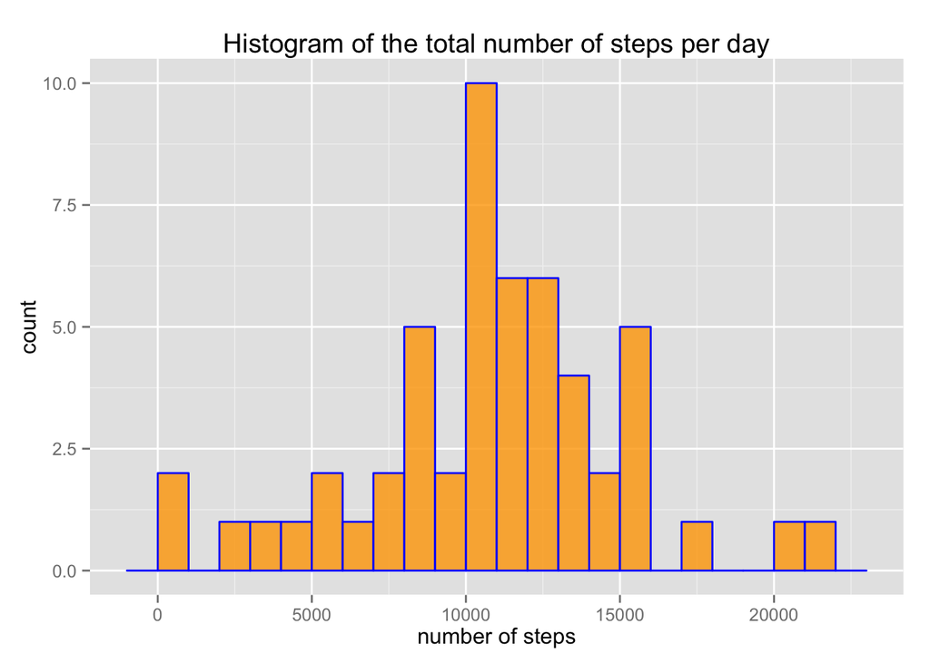

```r
library("ggplot2")
qplot(outdf$steps, geom="histogram",xlab="number of steps",alpha=I(0.8),col=I("blue"),fill=I("orange"),binwidth=1000,main="Histogram of the total number of steps per day")
```

2. Calculate the mean and the median total number of steps taken each day.

We now calculate some descriptive statistics of the data set in *outdf* and in particular the mean and the median total number of steps that were taken each day.

```r
mean(outdf$steps)
```

```
## [1] 10766.19
```

```r
median(outdf$steps)
```

```
## [1] 10765
```

The mean is 10766, rounded to the nearest integer and the median is 10765.

### PART III: What is the average daily pattern?

1. Make a time series plot of the 5-minute interval (x-axis) and the average number of steps taken, averaged across all days (y-axis)

We use the **aggregate** command to collapse the data by number of steps and intervals and call the built-in mean function. Using the ggplot2 graphics package, we create a time series plot of averaged number of steps by interval averaged across all days, as required.

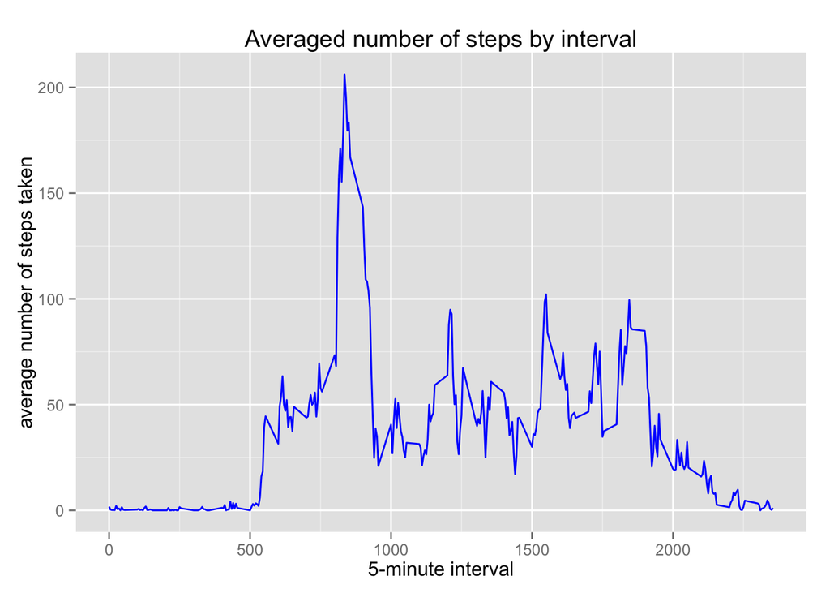

```r
 daily.activity<- aggregate(steps ~ interval,dfcomplete,FUN=mean)
 ggplot(daily.activity, aes(x =daily.activity$interval, y = daily.activity$steps))+geom_line(color="blue")+xlab("5-minute interval")+ylab("average number of steps taken")+ggtitle("Averaged number of steps by interval")
```

2. Which 5-minute interval, on average across all the days in the dataset, contains the maximum number of steps?

```r
 maxtab<-daily.activity[which.max(daily.activity$steps),]
 as.numeric(as.character(maxtab[[1]]))
```

```
## [1] 835
```

The maximum number of steps is contained in interval 835.

### PART IV: Imputing missing values

1. Calculate and report the total number of missing values in the dataset (i.e. the total number of rows with NAs)

```r
 sum(is.na(df))
```

```
## [1] 2304
```

The number of missing values is 2304.

2. Devise a strategy for filling in all of the missing values in the dataset.

The NA values correspond to 8 days of miising data. Here, we compute the averaged value corresponding to each interval in a given day in the week and assign it to missing values corresponding to that same day. For instance, if we have NA values over all intervals in a day corresponding to a Monday then, all non-missing Monday data is used to provide an averaged value to represent the NAs. The end of the following chunk code generates a data frame called **newdf** which is equal to the original data but with the missing values filled in.

```r
library("dplyr")
df$weekdays<-weekdays(df$date)
dfcomplete$weekdays<-weekdays(dfcomplete$date)
meanperday<-as.data.frame(with(dfcomplete, tapply(steps, list(interval, weekdays), mean)))
dfNA<-df[which(is.na(df)),]
for (i in 1:length(unique(dfNA$weekdays))){
    dfNA$steps<-replace(dfNA$steps, dfNA$weekdays==unique(dfNA$weekdays)[i],meanperday[unique(dfNA$weekdays)][[i]])
}
newdf<-rbind(dfcomplete, dfNA)%>%arrange(-desc(date))
```

Next, we plot a histogram of the total number of steps per day (missing values imputated)

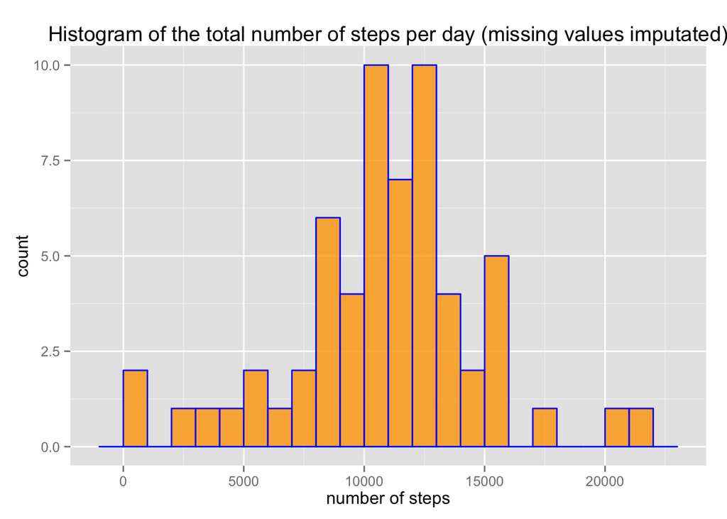

```r
newdf2 <- aggregate(steps ~ date, newdf,FUN=sum)
qplot(newdf2$steps, geom="histogram",xlab="number of steps",alpha=I(0.8),col=I("blue"),fill=I("orange"),binwidth=1000,main="Histogram of the total number of steps per day (missing values imputated)")
```

```r
mean(newdf2$steps)
```

```
## [1] 10821.21
```

```r
median(newdf2$steps)
```

```
## [1] 11015
```

## Part V: Are there differences in activity patterns between weekdays and weekends?

1. Create a new factor variable in the dataset with two levels – “weekday” and “weekend” indicating whether a given date is a weekday or weekend day.

```r
weekend<-c("Saturday","Sunday")
newdf$dayfactor<-as.factor(ifelse(newdf$weekdays %in% weekend,"weekend","weekday"))
```

2. Make a panel plot containing a time series plot of the 5-minute interval (x-axis) and the average number of steps taken, averaged across all weekday days or weekend days (y-axis).

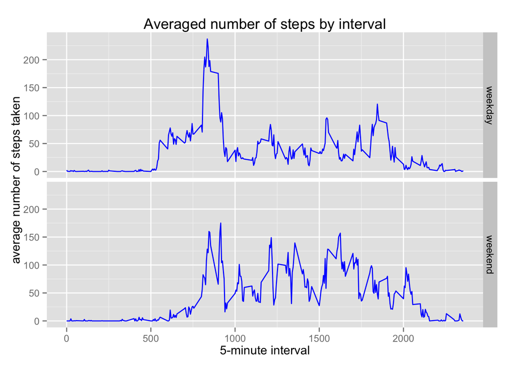

```r
daily.activity2<-aggregate(steps~interval+dayfactor,newdf,FUN=mean)
ggplot(daily.activity2, aes(x =interval, y = steps))+geom_line(color="blue")+xlab("5-minute interval")+ylab("average number of steps taken")+ggtitle("Averaged number of steps by interval")+facet_grid(dayfactor~.)
```